# Praktikum 6 MPDW

## Packages

```r
library(ggplot2)
library(tseries)
library(MASS)
library(forecast)
library(TSA)
library(TTR)
library(aTSA)
library(graphics)
library(readxl)
```

## Data Real

```r
data<-read_excel("C:\\Users\\aisya\\Documents\\MATKUL\\Semester 5\\MPDW\\Data Suhu Maksimum Delhi (2).xlsx")

datasuhu <- data$Suhu_Maks
datasuhu <- datasuhu[1:100]
datasuhu.ts<-ts(datasuhu)
```

### Eksplorasi Data

#### Plot Data Penuh

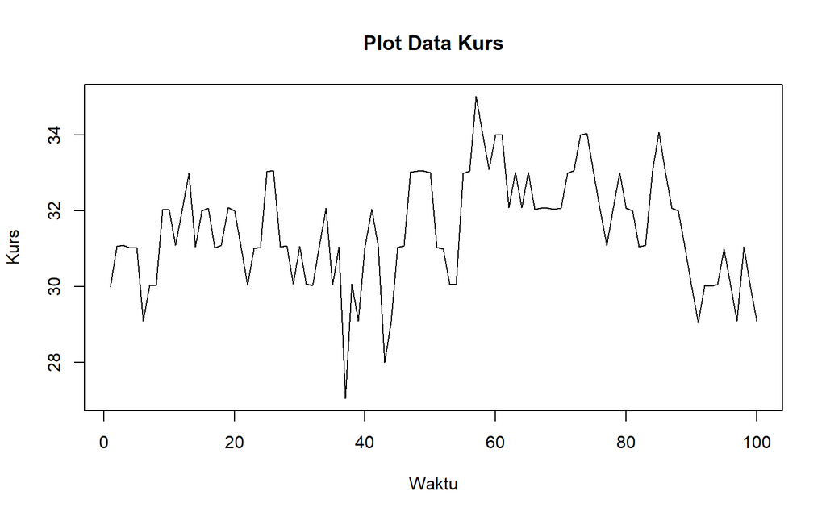

```r
plot.ts(datasuhu.ts,
        lty = 1,
        xlab = "Waktu",
        ylab = "Kurs",
        main = "Plot Data Kurs")
```

#### Plot Data Latih

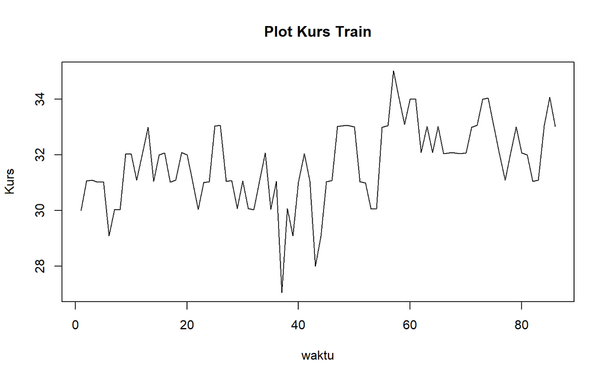

```r
kurstrain<-datasuhu[1:86]
train.ts<-ts(kurstrain)
plot.ts(train.ts, lty=1, xlab="waktu", ylab="Kurs", main="Plot Kurs Train")
```

Berdasarkan plot data deret waktu pada data latih, terlihat bahwa data cenderung memiliki trend yang naik dan cenderung tidak bergerak pada nilai tengah tertentu. Hal ini mengindikasikan bahwa data tidak stasioner dalam rataan.

#### Plot Data Uji

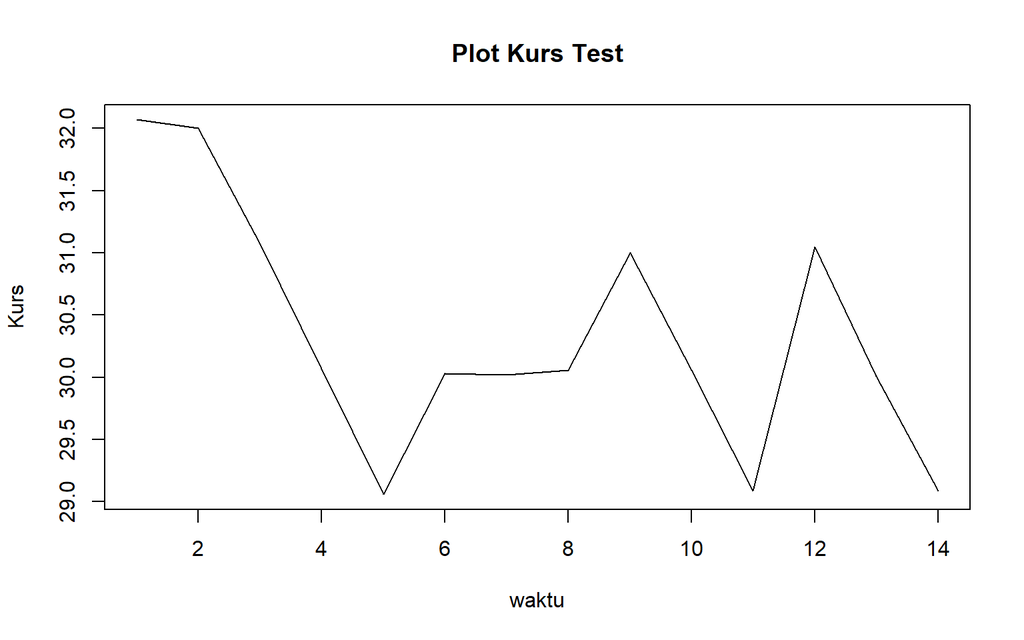

```r
kurstest<-datasuhu[87:100]
test.ts<-ts(kurstest)
plot.ts(test.ts, lty=1, xlab="waktu", ylab="Kurs", main="Plot Kurs Test")
```

### Uji Stasioneritas Data

#### Plot ACF

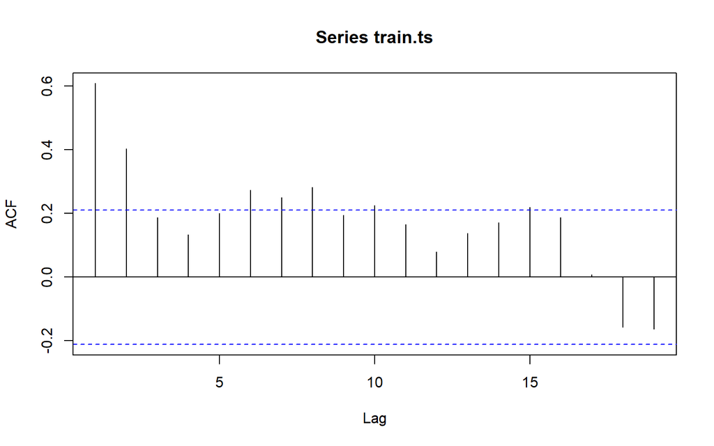

```r
acf(train.ts)
```

Berdasarkan plot ACF, terlihat bahwa plot ACF data menurun secara perlahan (*tails of slowly*). Hal ini juga menjadi indikasi bahwa data tidak stasioner dalam rataan

#### Uji ADF

```r
tseries::adf.test(train.ts)
```

```
##
##  Augmented Dickey-Fuller Test
##
## data:  train.ts
## Dickey-Fuller = -3.0603, Lag order = 4, p-value = 0.1405
## alternative hypothesis: stationary
```

$H_0$ : Data tidak stasioner dalam rataan

$H_1$ : Data stasioner dalam rataan

Berdasarkan uji ADF tersebut, didapat *p-value* sebesar 0.1405 yang lebih besar dari taraf nyata 5% sehingga tak tolak $H_0$ dan menandakan bahwa data tidak stasioner dalam rataan. Hal ini sesuai dengan hasil eksplorasi menggunakan plot time series dan plot ACF, sehingga ketidakstasioneran model kedepannya harus ditangani

#### Plot Box-Cox

```r
index <- seq(1:86)

# Box-Cox
bc <- boxcox(train.ts ~ index, lambda = seq(-2, 8, by = 0.1))
```

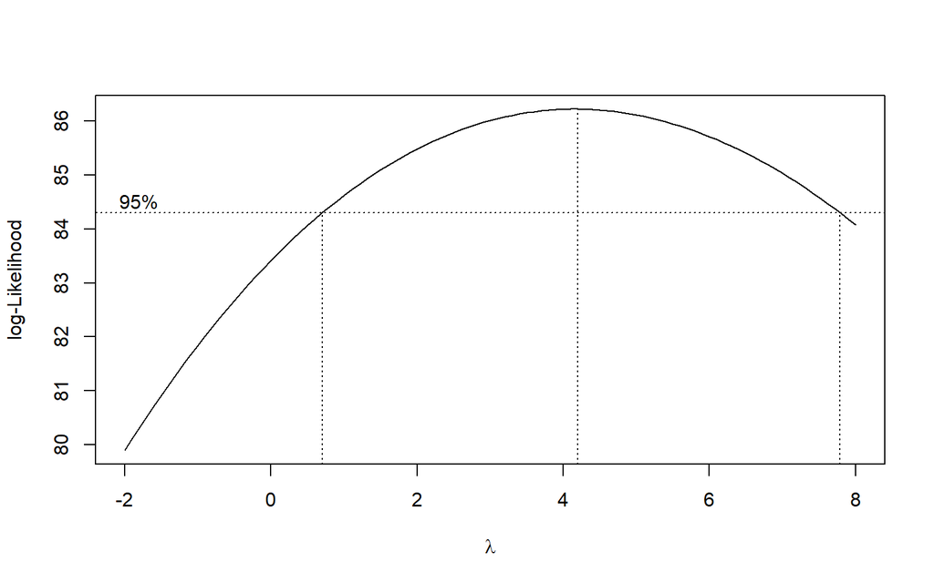

```r
# Nilai lambda optimum (rounded)
lambda_opt <- bc$x[which.max(bc$y)]
lambda_opt
```

```
## [1] 4.2
```

```r
# Selang kepercayaan 95% untuk lambda
ci_lambda <- bc$x[bc$y > max(bc$y) - 0.5 * qchisq(0.95, df = 1)]

# Batas bawah dan batas atas
ci_lower <- min(ci_lambda)
ci_upper <- max(ci_lambda)

c(Batas_Bawah = ci_lower, Batas_Atas = ci_upper)
```

```
## Batas_Bawah  Batas_Atas
##         0.8         7.7
```

### Penanganan Ketidakstasioneran Data

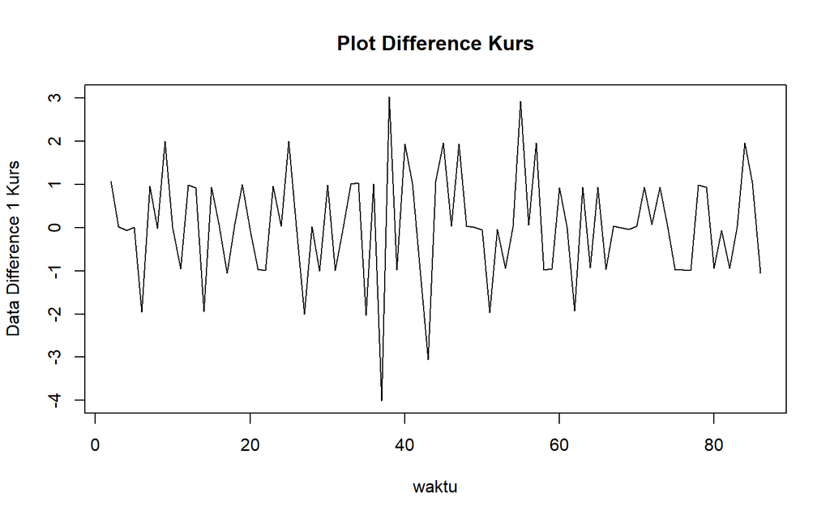

```r
# Dufferencing pertama
train.diff<-diff(train.ts,differences = 1)

# Plot hasil differencing
plot.ts(train.diff, lty=1, xlab="waktu", ylab="Data Difference 1 Kurs", main="Plot Difference Kurs")
```

Berdasarkan plot data deret waktu, terlihat bahwa data sudah stasioner dalam rataan ditandai dengan data bergerak pada nilai tengah tertentu (tidak terdapat trend ataupun musiman pada data)

#### Plot ACF

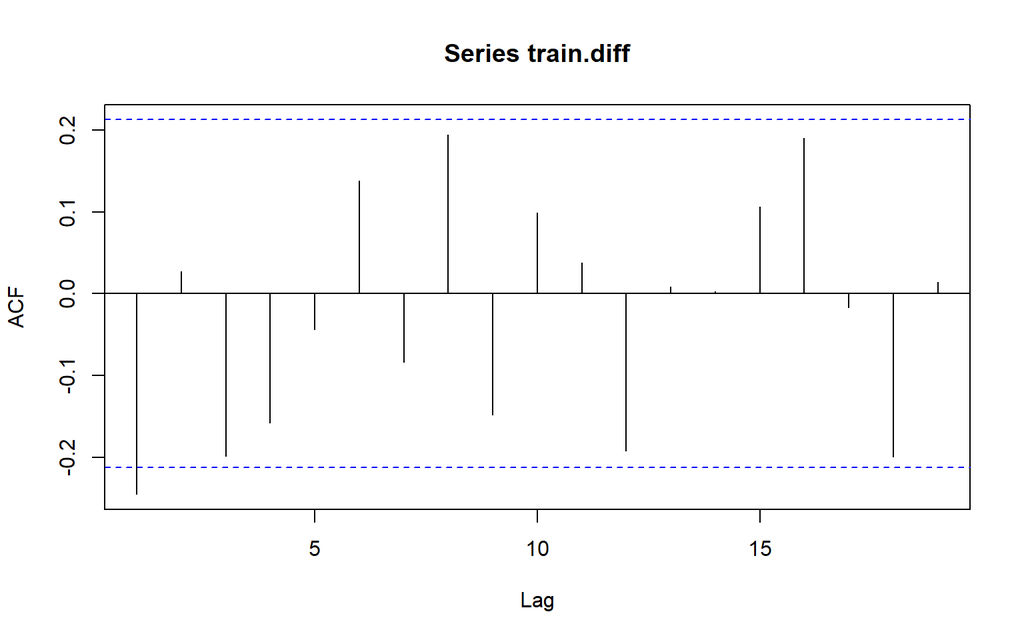

```r
acf(train.diff)
```

Berdasarkan plot tersebut, terlihat bahwa plot ACF cuts off pada lagke 1. Hal ini menandakan data sudah stasioner dalam rataan dan ketidakstasioneran data telah berhasil tertangani.

#### Uji ADF

```r
tseries::adf.test(train.diff)
```

```
##
##  Augmented Dickey-Fuller Test
##
## data:  train.diff
## Dickey-Fuller = -6.9449, Lag order = 4, p-value = 0.01
## alternative hypothesis: stationary
```

$H_0$ : Data tidak stasioner dalam rataan

$H_1$ : Data stasioner dalam rataan

Berdasarkan uji ADF tersebut, didapat *p-value* sebesar 0.01 yang lebih kecil dari taraf nyata 5% sehingga tolak $H_0$ atau data stasioner dalam rataan. Hal ini sesuai dengan hasil eksplorasi menggunakan plot time series dan plot ACF, sehingga dalam hal ini ketidakstasioneran data sudah berhasil ditangani dan dapat dilanjutkan ke pemodelan

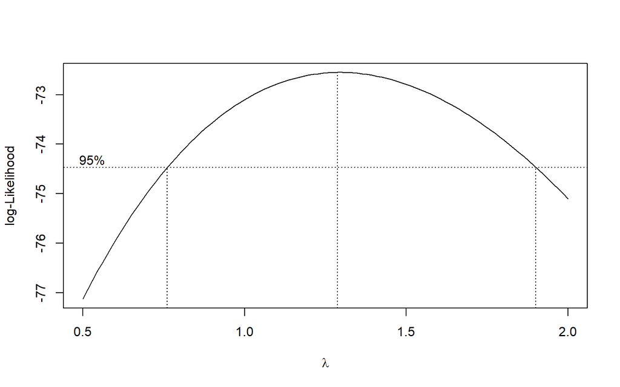

```r
library(MASS)

# 1. Sesuaikan panjang index karena differencing menghilangkan 1 observasi awal
index_diff <- seq(1:length(train.diff))

# 2. Cek apakah ada nilai negatif/nol. Jika ada, tambahkan konstanta (c)
# agar nilai minimum data menjadi > 0 (misalnya menjadi 1)
min_val <- min(train.diff)

if (min_val <= 0) {
  c <- abs(min_val) + 1
  train.diff_shifted <- train.diff + c
} else {
  train.diff_shifted <- train.diff
}

# 3. Plot Box-Cox pada data yang sudah di-shift
bc_diff <- boxcox(train.diff_shifted ~ index_diff, lambda = seq(0.5, 2, by = 0.1))
```

```r
# 4. Nilai lambda optimum (rounded)
lambda_opt_diff <- bc_diff$x[which.max(bc_diff$y)]
print(paste("Lambda optimum setelah diff:", lambda_opt_diff))
```

```
## [1] "Lambda optimum setelah diff: 1.28787878787879"
```

```r
# 5. Selang kepercayaan 95% untuk lambda
ci_lambda_diff <- bc_diff$x[bc_diff$y > max(bc_diff$y) - 0.5 * qchisq(0.95, df = 1)]

# Batas bawah dan batas atas
ci_lower_diff <- min(ci_lambda_diff)
ci_upper_diff <- max(ci_lambda_diff)

c(Batas_Bawah = ci_lower_diff, Batas_Atas = ci_upper_diff)
```

```
## Batas_Bawah  Batas_Atas
##   0.7727273   1.8939394
```

### Identifikasi Model

#### Plot ACF

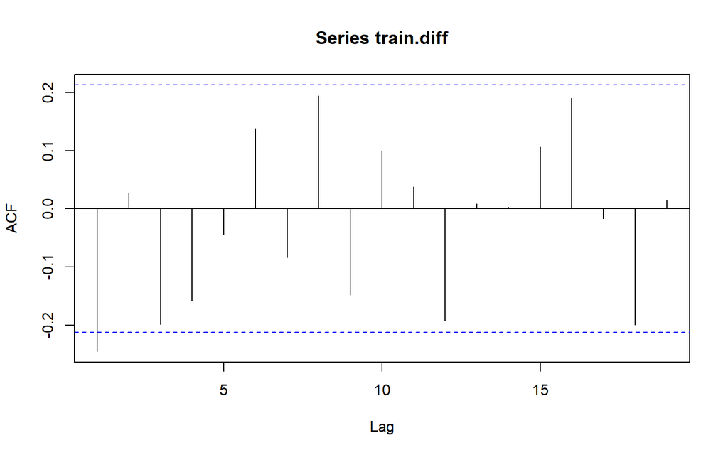

```r
acf(train.diff)
```

Berdasarkan plot tersebut, terlihat bahwa plot ACF cenderung *cuts off* pada lag ke 1, sehingga jika plot PACF dianggap *tails of*, maka model tentatifnya adalah ARIMA(0,1,1).

#### Plot PACF

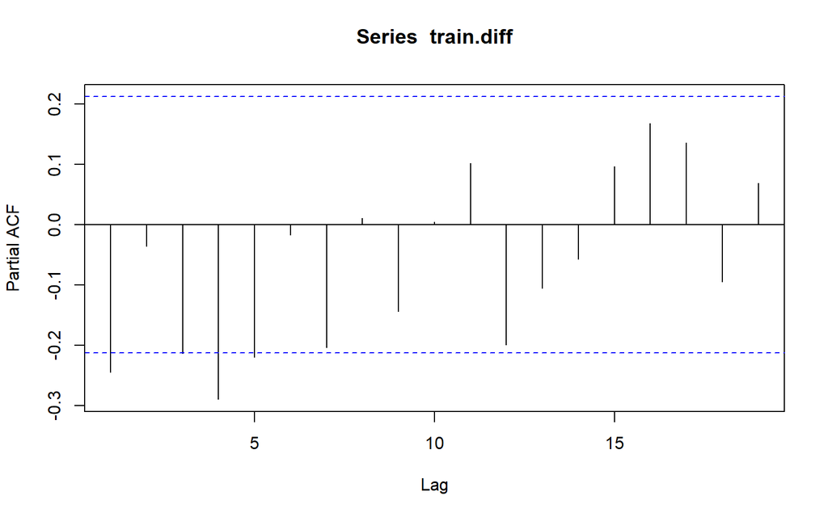

```r
pacf(train.diff)
```

Berdasarkan plot PACF, terdapat beberapa spike yang masih melewati batas signifikansi setelah lag pertama, sehingga tidak terlihat pola cut off yang jelas pada lag tertentu. Oleh karena itu, identifikasi model tidak hanya didasarkan pada PACF, tetapi juga mempertimbangkan hasil ACF dan EACF.

#### Plot EACF

```r
eacf(train.diff)
```

```
## AR/MA
##   0 1 2 3 4 5 6 7 8 9 10 11 12 13
## 0 x o o o o o o o o o o  o  o  o
## 1 o o o o o o o o o o o  o  o  o
## 2 o x o o o o o o o o o  o  o  o
## 3 x x o o o o o o o o o  o  o  o
## 4 x x o o o o o o o o o  o  o  o
## 5 o x x o o o o o o o o  o  o  o
## 6 o x o o o o o o o o o  o  o  o
## 7 o x x o o o o o o o o  o  o  o
```

Identifikasi model menggunakan plot EACF dilakukan dengan melihat ujung segitiga pada pola segitiga nol. Dalam hal ini model tentatif yang terbentuk adalah ARIMA(0,1,1), ARIMA(1,1,0), ARIMA(2,1,2), ARIMA(1,1,1)

### Pendugaan Parameter Model Tentatif

#### ARIMA(0,1,1)

```r
model1.da=Arima(train.diff, order=c(0,0,1),method="ML")
summary(model1.da)
```

```
## Series: train.diff
## ARIMA(0,0,1) with non-zero mean
##
## Coefficients:
##           ma1    mean
##       -0.3493  0.0337
## s.e.   0.1618  0.0851
##
## sigma^2 = 1.469:  log likelihood = -136.01
## AIC=278.02   AICc=278.31   BIC=285.35
##
## Training set error measures:
##                       ME     RMSE       MAE  MPE MAPE      MASE       ACF1
## Training set 0.004858467 1.197696 0.9268567 -Inf  Inf 0.5924209 0.06041408
```

```r
lmtest::coeftest(model1.da) #seluruh parameter signifikan
```

```
##
## z test of coefficients:
##
##            Estimate Std. Error z value Pr(>|z|)
## ma1       -0.349307   0.161834 -2.1584  0.03089 *
## intercept  0.033671   0.085097  0.3957  0.69234
## ---
## Signif. codes:  0 '***' 0.001 '**' 0.01 '*' 0.05 '.' 0.1 ' ' 1
```

#### ARIMA(1,1,0)

```r
model2.da=Arima(train.diff, order=c(1,0,0),method="ML")
summary(model2.da)
```

```
## Series: train.diff
## ARIMA(1,0,0) with non-zero mean
##
## Coefficients:
##           ar1    mean
##       -0.2464  0.0358
## s.e.   0.1053  0.1052
##
## sigma^2 = 1.49:  log likelihood = -136.59
## AIC=279.17   AICc=279.47   BIC=286.5
##
## Training set error measures:
##                       ME     RMSE       MAE  MPE MAPE      MASE        ACF1
## Training set 0.002622399 1.206326 0.9357125 -Inf  Inf 0.5980813 -0.00925163
```

```r
lmtest::coeftest(model2.da) #seluruh parameter signifikan
```

```
##
## z test of coefficients:
##
##            Estimate Std. Error z value Pr(>|z|)
## ar1       -0.246405   0.105325 -2.3395  0.01931 *
## intercept  0.035767   0.105223  0.3399  0.73392
## ---
## Signif. codes:  0 '***' 0.001 '**' 0.01 '*' 0.05 '.' 0.1 ' ' 1
```

#### ARIMA(2,1,2)

```r
model3.da=Arima(train.diff, order=c(2,0,2),method="ML")
summary(model3.da)
```

```
## Series: train.diff
## ARIMA(2,0,2) with non-zero mean
##
## Coefficients:
##           ar1     ar2      ma1      ma2    mean
##       -0.2752  0.4955  -0.2109  -0.7891  0.0265
## s.e.   0.1996  0.1204   0.1974   0.1961  0.0103
##
## sigma^2 = 1.243:  log likelihood = -128.89
## AIC=269.78   AICc=270.86   BIC=284.44
##
## Training set error measures:
##                        ME     RMSE       MAE MPE MAPE      MASE       ACF1
## Training set -0.004218814 1.081626 0.8562283 Inf  Inf 0.5472772 0.02863279
```

```r
lmtest::coeftest(model3.da) # hanya parameter 3 yang signifikan
```

```
##
## z test of coefficients:
##
##            Estimate Std. Error z value  Pr(>|z|)
## ar1       -0.275216   0.199614 -1.3787   0.16798
## ar2        0.495547   0.120401  4.1158 3.859e-05 ***
## ma1       -0.210887   0.197427 -1.0682   0.28544
## ma2       -0.789113   0.196150 -4.0230 5.746e-05 ***
## intercept  0.026484   0.010299  2.5716   0.01012 *
## ---
## Signif. codes:  0 '***' 0.001 '**' 0.01 '*' 0.05 '.' 0.1 ' ' 1
```

#### ARIMA(1,1,1)

```r
model4.da=Arima(train.diff, order=c(1,0,1),method="ML")
summary(model4.da)
```

```
## Series: train.diff
## ARIMA(1,0,1) with non-zero mean
##
## Coefficients:
##         ar1      ma1    mean
##       0.541  -1.0000  0.0263
## s.e.  0.093   0.0378  0.0099
##
## sigma^2 = 1.23:  log likelihood = -129.52
## AIC=267.03   AICc=267.53   BIC=276.8
##
## Training set error measures:
##                        ME     RMSE       MAE  MPE MAPE     MASE        ACF1
## Training set -0.005267386 1.089311 0.8467016 -Inf  Inf 0.541188 -0.01593555
```

```r
lmtest::coeftest(model4.da) #seluruh parameter signifikan
```

```
##
## z test of coefficients:
##
##             Estimate Std. Error  z value  Pr(>|z|)
## ar1        0.5410189  0.0929628   5.8197 5.894e-09 ***
## ma1       -0.9999989  0.0377531 -26.4879 < 2.2e-16 ***
## intercept  0.0262840  0.0099053   2.6535  0.007966 **
## ---
## Signif. codes:  0 '***' 0.001 '**' 0.01 '*' 0.05 '.' 0.1 ' ' 1
```

### Ringkasan AIC

```r
model_tentatif <- data.frame(
  Model = c("ARIMA(0,1,1)","ARIMA(1,1,0)","ARIMA(2,1,2)", "ARIMA(1,1,1)"),
  AIC   = c(AIC(model1.da),AIC(model2.da), AIC(model3.da), AIC(model4.da)),
  BIC   = c(BIC(model1.da),BIC(model2.da), BIC(model3.da), BIC(model4.da))
)

model_tentatif
```

```
##          Model      AIC      BIC
## 1 ARIMA(0,1,1) 278.0177 285.3456
## 2 ARIMA(1,1,0) 279.1707 286.4987
## 3 ARIMA(2,1,2) 269.7825 284.4384
## 4 ARIMA(1,1,1) 267.0324 276.8030
```

Berdasarkan pendugaan parameter di atas, nilai AIC terkecil dimiliki oleh model ARIMA(1,1,1) dan ARIMA(2,1,2). Selain itu, parameter model ARIMA(1,1,1) juga seluruhnya signifikan dan model ARIMA(2,1,2) signifikan di ar2 dan ma2 sehingga model yang dipilih adalah model ARIMA(1,1,1) dan ARIMA(2,1,2).

### Analisis Sisaan

Model terbaik hasil identifikasi kemudian dicek asumsi sisaannya. Sisaan model ARIMA harus memenuhi asumsi normalitas, kebebasan sisaan, dan kehomogenan ragam. Diagnostik model dilakukan secara eksplorasi dan uji formal.

#### Eksplorasi Sisaan model ARIMA(2,1,2)

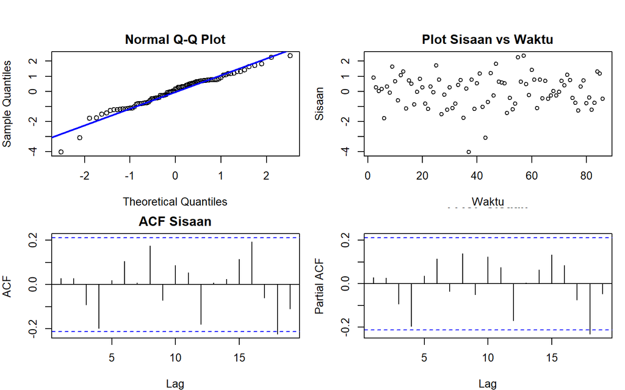

```r
sisaan.da <- model3.da$residuals

par(mfrow = c(2,2),
    mar = c(4,4,2,1),
    oma = c(0,0,2,0))

# Q-Q Plot
qqnorm(sisaan.da, main = "Normal Q-Q Plot")
qqline(sisaan.da, col = "blue", lwd = 2)

# Plot Sisaan vs Waktu
plot(sisaan.da, type = "p",
     main = "Plot Sisaan vs Waktu",
     xlab = "Waktu", ylab = "Sisaan")

# ACF
acf(sisaan.da, main = "ACF Sisaan")

# PACF
pacf(sisaan.da, main = "PACF Sisaan")
```

#### Uji Formal Model ARIMA(2,1,2)

```r
#1) Sisaan Menyebar Normal
ks.test(sisaan.da,"pnorm")  #gagal tolak H0 > sisaan menyebar normal
```

```
##
##  Exact one-sample Kolmogorov-Smirnov test
##
## data:  sisaan.da
## D = 0.081014, p-value = 0.6034
## alternative hypothesis: two-sided
```

Selain dengan eksplorasi, asumsi tersebut dapat diuji menggunakan uji formal. Pada tahapan ini uji formal yang digunakan untuk normalitas adalah uji Kolmogorov-Smirnov (KS). Hipotesis pada uji KS adalah sebagai berikut.

$H_0$ : Sisaan menyebar normal

$H_1$ : Sisaan tidak menyebar normal

Berdasarkan uji KS tersebut, didapat *p-value* sebesar 0.6034 yang lebih besar dari taraf nyata 5% sehingga tak tolak $H_0$ dan menandakan bahwa sisaan menyebar normal. Hal ini sesuai dengan hasil eksplorasi menggunakan plot kuantil-kuantil normal.

```r
#2) Sisaan saling bebas/tidak ada autokorelasi
Box.test(sisaan.da, type = "Ljung")  #gagal tolak H0 > sisaan saling bebas
```

```
##
##  Box-Ljung test
##
## data:  sisaan.da
## X-squared = 0.072175, df = 1, p-value = 0.7882
```

Selanjutnya akan dilakukan uji formal untuk kebebasan sisaan menggunakan uji Ljung-Box. Hipotesis yang digunakan adalah sebagai berikut.

$H_0$ : Sisaan saling bebas

$H_1$ : Sisaan tidak tidak saling bebas

```r
#3) Sisaan homogen
Box.test((sisaan.da)^2, type = "Ljung")  #gagal tolak H0 > sisaan homogen
```

```
##
##  Box-Ljung test
##
## data:  (sisaan.da)^2
## X-squared = 1.3176, df = 1, p-value = 0.251
```

Hipotesis yang digunakan untuk uji kehomogenan ragam adalah sebagai berikut.

$H_0$ : Ragam sisaan homogen

$H_1$ : Ragam sisaan tidak homogen

Berdasarkan uji Ljung-Box terhadap sisaan kuadrat tersebut, didapat *p-value* sebesar 0.251 yang lebih besar dari taraf nyata 5% sehingga gagal tolak $H_0$ dan menandakan bahwa ragam sisaan homogen.

```r
#4) Nilai tengah sisaan sama dengan nol
t.test(sisaan.da, mu = 0, conf.level = 0.95)  #gagal tolak h0 > nilai tengah sisaan sama dengan 0
```

```
##
##  One Sample t-test
##
## data:  sisaan.da
## t = -0.035748, df = 84, p-value = 0.9716
## alternative hypothesis: true mean is not equal to 0
## 95 percent confidence interval:
##  -0.2389029  0.2304653
## sample estimates:
##    mean of x
## -0.004218814
```

Terakhir, dengan uji-t, akan dicek apakah nilai tengah sisaan sama dengan nol. Hipotesis yang diujikan sebagai berikut.

$H_0$ : nilai tengah sisaan sama dengan 0

$H_1$ : nilai tengah sisaan tidak sama dengan 0

Berdasarkan uji tersebut, didapat *p-value* sebesar 0.9716 yang lebih besar dari taraf nyata 5% sehingga gagal tolak $H_0$ dan menandakan bahwa nilai tengah sisaan sama dengan nol.

#### Eksplorasi Sisaan model ARIMA(1,1,1)

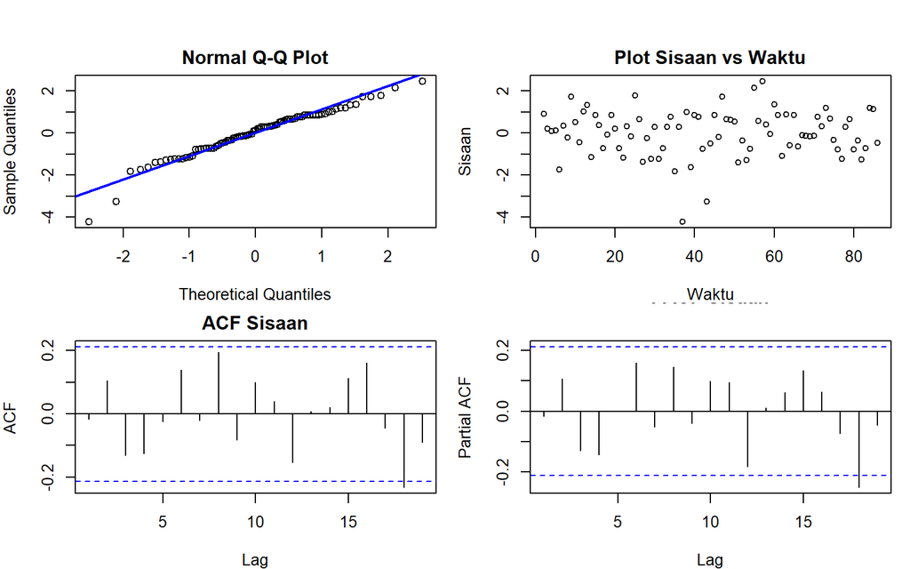

```r
sisaan.da4 <- model4.da$residuals

par(mfrow = c(2,2),
    mar = c(4,4,2,1),
    oma = c(0,0,2,0))

# Q-Q Plot
qqnorm(sisaan.da4, main = "Normal Q-Q Plot")
qqline(sisaan.da4, col = "blue", lwd = 2)

# Plot Sisaan vs Waktu
plot(sisaan.da4, type = "p",
     main = "Plot Sisaan vs Waktu",
     xlab = "Waktu", ylab = "Sisaan")

# ACF
acf(sisaan.da4, main = "ACF Sisaan")

# PACF
pacf(sisaan.da4, main = "PACF Sisaan")
```

#### Uji Formal Model ARIMA(1,1,1)

```r
#1) Sisaan Menyebar Normal
ks.test(sisaan.da4,"pnorm")  #gagal tolak H0 > sisaan menyebar normal
```

```
##
##  Exact one-sample Kolmogorov-Smirnov test
##
## data:  sisaan.da4
## D = 0.083038, p-value = 0.5722
## alternative hypothesis: two-sided
```

Selain dengan eksplorasi, asumsi tersebut dapat diuji menggunakan uji formal. Pada tahapan ini uji formal yang digunakan untuk normalitas adalah uji Kolmogorov-Smirnov (KS). Hipotesis pada uji KS adalah sebagai berikut.

$H_0$ : Sisaan menyebar normal

$H_1$ : Sisaan tidak menyebar normal

Berdasarkan uji KS tersebut, didapat *p-value* sebesar 0.5722 yang lebih besar dari taraf nyata 5% sehingga tak tolak $H_0$ dan menandakan bahwa sisaan menyebar normal. Hal ini sesuai dengan hasil eksplorasi menggunakan plot kuantil-kuantil normal.

```r
#2) Sisaan saling bebas/tidak ada autokorelasi
Box.test(sisaan.da4, type = "Ljung")  #gagal tolak H0 > sisaan saling bebas
```

```
##
##  Box-Ljung test
##
## data:  sisaan.da4
## X-squared = 0.022356, df = 1, p-value = 0.8811
```

Selanjutnya akan dilakukan uji formal untuk kebebasan sisaan menggunakan uji Ljung-Box. Hipotesis yang digunakan adalah sebagai berikut.

$H_0$ : Sisaan saling bebas

$H_1$ : Sisaan tidak tidak saling bebas

```r
#3) Sisaan homogen
Box.test((sisaan.da4)^2, type = "Ljung")  #gagal tolak H0 > sisaan homogen
```

```
##
##  Box-Ljung test
##
## data:  (sisaan.da4)^2
## X-squared = 1.0524, df = 1, p-value = 0.305
```

Hipotesis yang digunakan untuk uji kehomogenan ragam adalah sebagai berikut.

$H_0$ : Ragam sisaan homogen

$H_1$ : Ragam sisaan tidak homogen

Berdasarkan uji Ljung-Box terhadap sisaan kuadrat tersebut, didapat *p-value* sebesar 0.305 yang lebih besar dari taraf nyata 5% sehingga gagal tolak $H_0$ dan menandakan bahwa ragam sisaan homogen.

```r
#4) Nilai tengah sisaan sama dengan nol
t.test(sisaan.da4, mu = 0, conf.level = 0.95)  #gagal tolak h0 > nilai tengah sisaan sama dengan 0
```

```
##
##  One Sample t-test
##
## data:  sisaan.da4
## t = -0.044319, df = 84, p-value = 0.9648
## alternative hypothesis: true mean is not equal to 0
## 95 percent confidence interval:
##  -0.2416180  0.2310833
## sample estimates:
##    mean of x
## -0.005267386
```

Terakhir, dengan uji-t, akan dicek apakah nilai tengah sisaan sama dengan nol. Hipotesis yang diujikan sebagai berikut.

$H_0$ : nilai tengah sisaan sama dengan 0

$H_1$ : nilai tengah sisaan tidak sama dengan 0

Berdasarkan uji tersebut, didapat *p-value* sebesar 0.9648 yang lebih besar dari taraf nyata 5% sehingga gagal tolak $H_0$ dan menandakan bahwa nilai tengah sisaan sama dengan nol.

Berdasarkan hasil uji residual, baik ARIMA(1,1,1) maupun ARIMA(2,1,2) sama-sama memenuhi seluruh asumsi (normalitas, kebebasan sisaan, kehomogenan ragam, dan nilai tengah nol). ARIMA(2,1,2) masih memenuhi diagnostik residual, tetapi ARIMA(1,1,1) memiliki struktur yang lebih sederhana dan seluruh parameternya signifikan, sehingga dipilih berdasarkan prinsip parsimoni.

### Overfitting

Tahapan selanjutnya adalah overfitting dilakukan dengan menaikkan orde AR(p) dan MA(q) dari model ARIMA(1,1,1) Kandidat model yang diuji adalah ARIMA(2,1,1) dan ARIMA(1,1,2).

```r
model5.da=Arima(train.diff, order=c(2,0,1),method="ML")
summary(model5.da)
```

```
## Series: train.diff
## ARIMA(2,0,1) with non-zero mean
##
## Coefficients:
##          ar1     ar2     ma1    mean
##       0.5281  0.0251  -1.000  0.0264
## s.e.  0.1088  0.1091   0.037  0.0101
##
## sigma^2 = 1.245:  log likelihood = -129.49
## AIC=268.98   AICc=269.74   BIC=281.19
##
## Training set error measures:
##                        ME     RMSE       MAE  MPE MAPE      MASE        ACF1
## Training set -0.005013428 1.089287 0.8494559 -Inf  Inf 0.5429485 0.001774911
```

```r
lmtest::coeftest(model5.da) #parameter ar1 dan ma1 signifikan
```

```
##
## z test of coefficients:
##
##            Estimate Std. Error  z value  Pr(>|z|)
## ar1        0.528080   0.108759   4.8555 1.201e-06 ***
## ar2        0.025099   0.109149   0.2300  0.818128
## ma1       -0.999995   0.037029 -27.0057 < 2.2e-16 ***
## intercept  0.026360   0.010141   2.5994  0.009339 **
## ---
## Signif. codes:  0 '***' 0.001 '**' 0.01 '*' 0.05 '.' 0.1 ' ' 1
```

```r
model6.da=Arima(train.diff, order=c(1,0,2),method="ML")
summary(model6.da)
```

```
## Series: train.diff
## ARIMA(1,0,2) with non-zero mean
##
## Coefficients:
##          ar1      ma1     ma2    mean
##       0.5615  -1.0283  0.0283  0.0263
## s.e.  0.1443   0.1617  0.1573  0.0101
##
## sigma^2 = 1.245:  log likelihood = -129.5
## AIC=269   AICc=269.76   BIC=281.21
##
## Training set error measures:
##                        ME     RMSE       MAE  MPE MAPE      MASE         ACF1
## Training set -0.005110258 1.089304 0.8484155 -Inf  Inf 0.5422835 -0.005248741
```

```r
lmtest::coeftest(model6.da) #parameter ar1 dan ma1 signifikan
```

```
##
## z test of coefficients:
##
##            Estimate Std. Error z value  Pr(>|z|)
## ar1        0.561493   0.144341  3.8901 0.0001002 ***
## ma1       -1.028253   0.161692 -6.3593 2.026e-10 ***
## ma2        0.028254   0.157336  0.1796 0.8574848
## intercept  0.026332   0.010054  2.6191 0.0088168 **
## ---
## Signif. codes:  0 '***' 0.001 '**' 0.01 '*' 0.05 '.' 0.1 ' ' 1
```

Kedua kandidat overfitting menambahkan parameter yang tidak signifikan dan AIC-nya lebih besar dibanding model dasar. Sesuai prinsip parsimoni, model yang lebih sederhana (ARIMA(1,1,1)) tetap dipilih karena penambahan parameter tidak memberi pengaruh berarti

### Model Terbaik : ARIMA(1,1,1)

### Peramalan

```r
# ---FORECAST---
ramalan.da <- forecast::forecast(model4.da, h = length(test.ts))
```

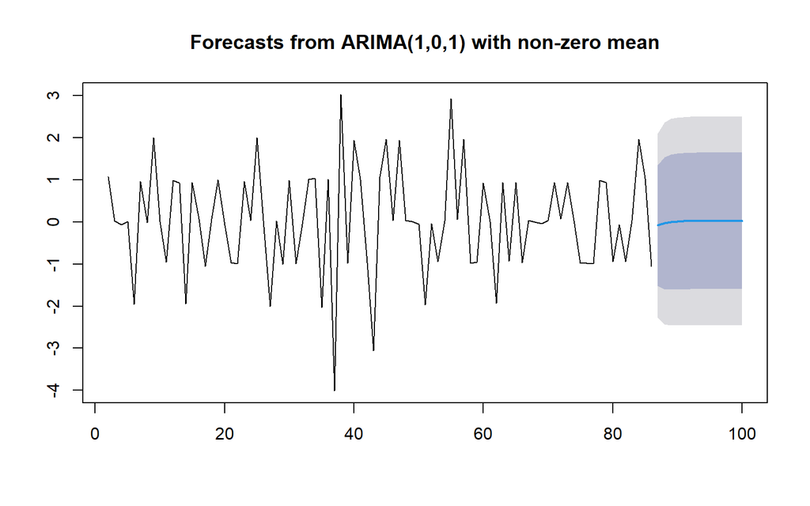

```r
data.ramalan.da <- ramalan.da$mean
plot(ramalan.da)
```

```r
# Inverse differencing
pt_akhir_train <- tail(train.ts, 1)

forecast <- diffinv(data.ramalan.da, differences = 1, xi = pt_akhir_train)
hasil <- forecast[-1]
hasil <- forecast[1:length(test.ts)]

# Bandingkan aktual vs forecast
perbandingan.da <- cbind(
  Aktual   = test.ts,
  Forecast = hasil
)

print(head(perbandingan.da, 10))
```

```
## Time Series:
## Start = 1
## End = 10
## Frequency = 1
##    Aktual Forecast
##  1  32.07 33.03000
##  2  32.00 32.94663
##  3  31.07 32.91358
##  4  30.07 32.90777
##  5  29.06 32.91669
##  6  30.03 32.93358
##  7  30.02 32.95478
##  8  30.06 32.97831
##  9  31.00 33.00311
## 10  30.06 33.02859
```

```r
# Hitung akurasi
akurasi_test <- accuracy(hasil, test.ts)
akurasi_test
```

```
##                 ME     RMSE      MAE       MPE     MAPE     ACF1 Theil's U
## Test set -2.664817 2.832239 2.664817 -8.890602 8.890602 0.337193  2.986708
```

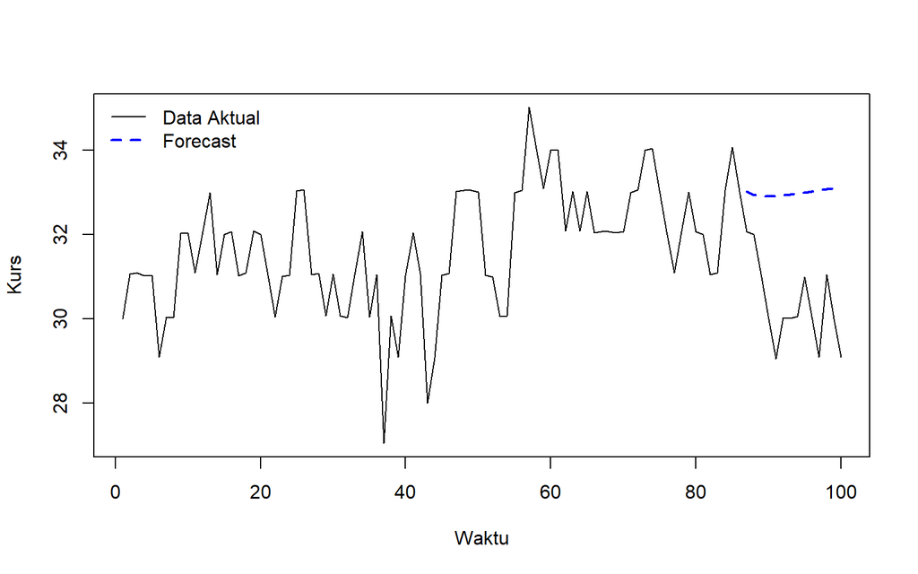

```r
# Plot data
ts.plot(datasuhu.ts, col = "black", lty = 1,
        xlab = "Waktu", ylab = "Kurs")

# Garis forecast
lines(87:(86+length(hasil)), hasil, col = "blue", lty = 2, lwd = 2)
legend("topleft",
       legend = c("Data Aktual", "Forecast"),
       col = c("black", "blue"),
       lty = c(1,2,3), lwd = c(1,2,1), bty = "n")
```

Berdasarkan hasil identifikasi, estimasi parameter, diagnostik residual, dan perbandingan model, ARIMA(1,1,1) dipilih sebagai model akhir. Evaluasi pada data uji kemudian digunakan untuk melihat kemampuan model dalam melakukan peramalan.